# Progetto Statistical Learning

Lorenzo De Simoni

2025-01-10

## 1 Introduzione

Questo progetto ha come obiettivo quello di identificare il modello migliore, in termini di precisione e complessità, per prevedere il valore in dollari dei calciatori al giorno d’oggi rispecchiando le doti tecniche e fisiche del giocatore. Il problema d’interesse è una questione attuale che vede coinvolti i settori giovanili di molte squadre di categorie minori in Italia, in quanto risulta spesso complesso attribuire un valore al giocatore che rispecchi effettivamente le sue abilità. Queste difficoltà vengono spesso riscontrate sia dalle squadre che sono interessate ad acquistare nuovi calciatori, sia da quelle che devono vendere, in quanto i prezzi sono spesso influenzati da interessi volti a regolarizzare il bilancio della società. Ovviamente il valore del giocatore non è il risultato solo delle sue doti tecnico-tattiche ma agiscono su di esso variabili latenti, che non sempre sono quantificabili numericamente. Per realizzare questo progetto ho utilizzato un dataset, trovato su Kaggle, che ha 5682 osservazioni e 41 variabili, tra cui “Value” che indica il valore dei calciatori in dollari. Le altre variabili sono il nome, la nazione, l’età, la squadra di appartenenza del giocatore, altezza, peso e tutti gli overall da 0 a 100 delle principali statistiche di ogni calciatore. È stata presa come proxy delle abilità dei giocatori tecniche e fisiche gli overall score del videogame FC24.

## 1.1 Preprocessing

Inizialmente ho deciso di rimuovere le variabili qualitative come il nome, la nazione, ed il club di appartenenza del calciatore dal dataset ,per implementare i modelli scelti, in quanto non sono d’interesse per il problema in esame. La variabile Value in quanto indicata in dollari l’ho resa di tipo numeric, eliminando il simbolo del dollaro ed il punto di divisione con la funzione gsub().

```r
#importo dati
data <- read.csv('player_stats.csv')
#struttura dati
library(pillar)
glimpse(data)
```

```
## Rows: 5,682
## Columns: 41
## $ player         <chr> "Cristian Castro Devenish", "Silaldo Taffarel", "Thomas…
## $ country        <chr> "Colombia", "Brazil", "Germany", "Austria", "Uruguay", …
## $ height         <int> 192, 181, 193, 187, 191, 183, 194, 185, 189, 173, 186, …
## $ weight         <int> 84, 80, 84, 86, 80, 83, 88, 75, 80, 67, 78, 65, 88, 67,…
## $ age            <int> 22, 31, 29, 33, 23, 31, 25, 20, 30, 22, 23, 31, 21, 29,…
## $ club           <chr> "Atl. Nacional ", "Corinthians ", "Holstein Kiel ", "SK…
## $ ball_control   <int> 55, 69, 25, 46, 14, 20, 52, 41, 68, 65, 62, 61, 45, 54,…
## $ dribbling      <int> 43, 70, 12, 48, 8, 16, 43, 33, 67, 67, 59, 59, 28, 51, …
## $ marking        <chr> "", "", "", "", "", "", "", "", "", "", "", "", "", "",…
## $ slide_tackle   <int> 68, 56, 13, 66, 14, 13, 71, 65, 16, 30, 30, 58, 54, 50,…
## $ stand_tackle   <int> 73, 58, 16, 69, 16, 17, 72, 70, 22, 33, 24, 59, 58, 51,…
## $ aggression     <int> 72, 62, 27, 71, 28, 27, 63, 46, 61, 40, 51, 60, 50, 86,…
## $ reactions      <int> 68, 70, 65, 64, 50, 70, 61, 54, 64, 47, 58, 58, 50, 55,…
```

[output cut: 28 more lines]

```r
#rimozione variabili
x <- data[,c(3,4,5,7,8,10:41)]

#rendo la variabile value di tipo numeric
x$value <- gsub('\\$','', x$value)
x$value <- gsub('\\.','', x$value)
x$value <- as.numeric(x$value)
```

Ho stampato un corrplot per farmi un’idea delle varie correlazioni presenti tra le variabili utilizzando il comando corrplot() della libreria corrplot, e per capire quali variabili influenzassero maggiormente la variabile risposta. Oltre al corrplot ho stampato anche un boxplot di “value” per identificare possibili outlier e farmi un’idea della sua variabilità.

```r
#studio correlazione
library(corrplot)
```

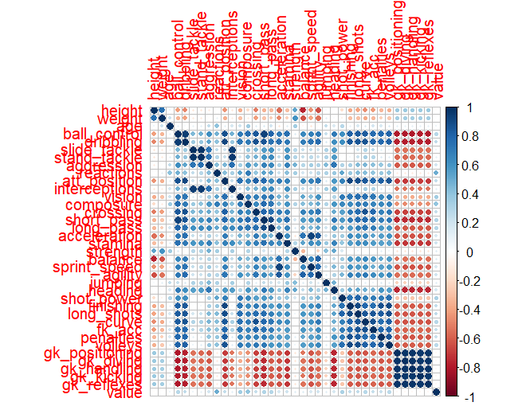

```r
corrplot(cor(x), method = 'circle')
```

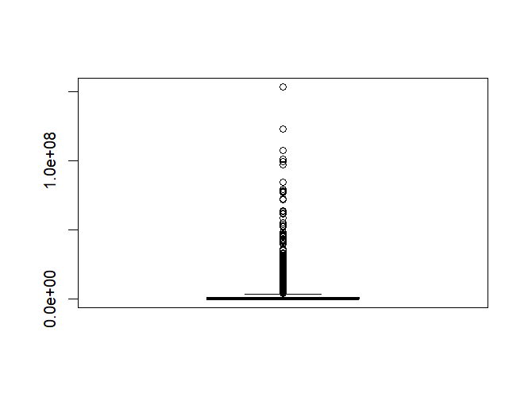

```r
boxplot(x$value)
```

Si può notare che la variabile value è correlata positivamente solo con la variabile reactions. I valori di Value hanno una varianza altissima ed una distribuzione molto asimmetrica.

Successivamente attraverso l’utilizzo della libreria Caret ho diviso il dataset in train set e test set, utilizzando l’80% delle osservazioni per il train e le restanti come test.

```r
#divisione in train e test
library(caret)
index <- createDataPartition(x$value, p = 0.8)$Resample1
x_train <- x[index,]
x_test <- x[-index,]
```

## 2 Modelli Tree-Based

In primo luogo ho voluto implementare dei modelli Tree-Based per capire la complessità dei dati e quanto fossero precisi nel prevedere la variabile Value, attraverso algoritmi Bagging, Boosting e Random Forest.

## 2.1 Bagging

Per quanto riguarda il Bagging per implementarlo ho utilizzato la funzione randomForest() del pacchetto RandomForest, impostando il parametro mtry = 36 ovvero pari al numero di variabili che vengono considerate per lo split per ogni albero. Il parametro importance = TRUE serve per calcolare e restituire una misura di importanza delle variabili utilizzate nel modello. In particolare si può notare che la variabile reactions è quella che ha avuto il maggiore impatto nel determinare il risultato del modello, come mi sarei aspettato visto il corrplot(). In questo caso per valutare le prestazioni del mio modello e confrontare la sua capacità previsiva con gli altri che sono stati implementati, ho utilizzato il Mean Absolute Error, ed ho effettuato una k-fold cross validation con k = numero di fold = 4. Con il Bagging ho ottenuto un Mean absolute error pari a 776228.7$.

```r
#Bagging
library(randomForest)

#Inizializzazione cv
k <- 4
indices <- sample(1:nrow(x_train))
folds <- cut(indices, breaks = k, labels = FALSE)
all_mae_bag <- NULL
all_mae_train_bag <- NULL

set.seed(123)

for (i in 1:k) {
  cat("processing fold #", i, "\n")
  val_indices <- which(folds == i, arr.ind = TRUE) #divisione train e validation
  val_data <- x_train[val_indices,]
  val_targets <- x_train[val_indices,37]

  partial_train_data <- x_train[-val_indices,]
  partial_train_targets <- x_train[-val_indices,37]
  #implementazione modello
  set.seed(123)
  model.bag <- randomForest(value ~., data= partial_train_data , importance=TRUE, mtry = 36)

  # Storing all mae values
  y_bag <- predict(model.bag, newdata = as.data.frame(val_data))
  mae_bag <- mean(abs(val_targets-y_bag))
  all_mae_bag <- rbind(all_mae_bag, mae_bag)

  y_bag_train <- predict(model.bag, newdata = as.data.frame(partial_train_data))
  mae_bag_train <- mean(abs(partial_train_targets-y_bag_train))
  all_mae_train_bag <- rbind(all_mae_train_bag,mae_bag_train)

}
#importanza variabili
model.bag$importance


#mae
mae_validation_bag <- mean(all_mae_bag)
mae_validation_bag
```

```
##                      %IncMSE IncNodePurity
## height          1.045290e+11  5.831558e+14
## weight          6.224692e+10  7.993082e+14
## age             1.543299e+12  3.372238e+15
## ball_control    1.960157e+12  7.288580e+15
## dribbling       1.943947e+12  6.195215e+15
## slide_tackle    6.358700e+11  2.009563e+15
## stand_tackle    4.586175e+11  1.592533e+15
## aggression      2.433367e+11  6.378000e+14
## reactions       6.400421e+13  1.532024e+17
## att_position    2.722167e+10  1.049003e+15
## interceptions   1.183614e+11  6.852667e+14
## vision          1.685010e+11  6.323379e+14
## composure       6.169703e+11  1.247901e+15
## crossing        2.099601e+11  5.369636e+14
## short_pass      4.840510e+11  1.634025e+15
## long_pass       1.657277e+11  7.237635e+14
## acceleration    1.671808e+11  6.853009e+14
## stamina         7.148738e+11  1.855078e+15
## strength        1.561380e+11  5.643765e+14
## balance         8.588767e+10  4.182946e+14
## sprint_speed    5.481389e+11  2.149677e+15
## agility         7.523553e+10  2.722977e+14
## jumping        -6.101351e+10  4.806801e+14
## heading         9.987382e+10  7.011624e+14
## shot_power      4.103465e+10  6.380729e+14
## finishing       3.818843e+11  2.322832e+15
## long_shots      5.954731e+10  3.591039e+14
## curve           1.629795e+10  3.057025e+14
## fk_acc          1.052877e+11  3.287738e+14
## penalties       3.659038e+10  7.447580e+14
## volleys         3.142340e+11  6.062137e+14
## gk_positioning -1.079899e+11  7.773624e+14
## gk_diving       5.524149e+10  1.264149e+15
## gk_handling     1.423117e+11  7.360567e+14
## gk_kicking     -5.582005e+10  6.124918e+14
## gk_reflexes     1.806805e+11  1.587087e+15
```

```
## [1] 776228.7
```

## 2.2 Boosting

In seguito, ho implementato un algoritmo di Boosting per provare a migliorare le prestazioni previsive dei miei modelli. Il modello è stato implementato utilizzando la funzione gbm(), presente nella libreria gbm. Anche in questo caso ho effettuato una cross validation con il numero di folds = k = 4. In questo caso ho impostato il parametro di shrinkage, ovvero il learning rate, pari a 0.06, in quanto dopo diverse prove ho visto che era il valore che mi forniva i risultati migliori. Per quanto riguarda la funzione di loss inizialmente ho provato ad utilizzare “Gaussian” che ipotizza una loss di tipo Mse, ma non ottenendo risultati soddisfacenti ho scelto di impostare il parametro distribution = “Laplace”, per utilizzare una loss di tipo Mae. Ho utilizzato 5000 alberi per il mio modello ed infine ho calcolato il Mean absolute error per confrontare la capacità previsiva del modello con il Bagging implementato in precedenza. In questo caso ho ottenuto un Mae = 903128.3$.

```r
all_mae_boost <- NULL
all_mae_train_boost <- NULL


library(gbm)



for (i in 1:k) {
  cat("processing fold #", i, "\n")
  set.seed(123)
  boost.model <- gbm(value ~ ., data = as.data.frame(partial_train_data),
                              distribution = "laplace", n.trees = 5000,
                              shrinkage = 0.06, verbose = F)



  # Storing all mae values
  y_boost <- predict(boost.model, newdata = as.data.frame(val_data), n.trees=5000)
  mae_boost <- mean(abs(val_targets-y_boost))
  all_mae_boost <- rbind(all_mae_boost, mae_boost)

  y_boost_train <- predict(boost.model, newdata = as.data.frame(partial_train_data), n.trees = 5000)
  mae_boost_train <- mean(abs(partial_train_targets-y_boost_train))
  all_mae_train_boost <- rbind(all_mae_train_boost,mae_boost_train)

}

mae_validation_boost <- mean(all_mae_boost)
mae_validation_boost
```

```
## [1] 903128.3
```

## 2.3 Random Forest

Dopo aver provato ad utilizzare il Boosting ed aver notato che mi forniva un errore maggiore rispetto al Bagging ho voluto implementare una Random Forest per capire se funzionasse meglio rispetto al Bagging in quanto vado ad impostare un m.try minore, ovvero il numero di variabili selezionate casualmente tra tutte, da cui scelgo con quale effettuare lo split. È stata effettuata una cross validation sempre con k = 4.

Visto il problema di regressione che sto affrontando ho deciso di impostare i parametri nel seguente modo:

-nodesize, che rappresenta la misura minima di ogni nodo terminale, per un problema di regressione solitamente è uguale a 5.

Utilizzando lo stesso validation e partial train dataset utilizzati per gli altri algoritmi ho ottenuto un Mean absolute error, mae = 685188.4$. Come mi sarei aspettato per ora è l’algoritmo che funziona meglio per prevedere il valore in dollari dei calciatori sulla base delle statistiche dei giocatore.

```r
all_mae_rf <- NULL
all_mae_train_rf <- NULL

for (i in 1:k) {
  cat("processing fold #", i, "\n")
  set.seed(123)
  rf.model <- randomForest(value ~., data = partial_train_data ,mtry = 12, nodesize = 5) #p/3 come m
  # Storing all mae values
  y_rf <- predict(rf.model, newdata = as.data.frame(val_data))
  mae_rf <- mean(abs(val_targets-y_rf))
  all_mae_rf <- rbind(all_mae_rf, mae_rf)

  y_rf_train = predict(rf.model, newdata = as.data.frame(partial_train_data))
  mae_rf_train <- mean(abs(partial_train_targets-y_rf_train))
  all_mae_train_rf <- rbind(all_mae_train_rf , mae_rf_train)

}

mae_validation_rf <- mean(all_mae_rf)
mae_validation_rf
```

```r
mae_validation_rf
```

```
## [1] 685188.4
```

## Neural Network

Come ultimo algoritmo ho voluto provare ad implementare una rete neurale per capire la sua potenza previsiva in un problema di questo tipo e per provare a migliorare i risultati ottenuti con gli algoritmi tree-based, nonostante la sua natura di algoritmo black box ed il problema della difficoltà interpretativa. Per prima cosa ho scalato le x utilizzando per la parte di test media e varianza del train. Poi ho impostato una cross validation, sempre con k=4 e provato diversi valori per il numero di epoche.

```r
library(keras)


#normalizzo i dati
x_train_nn <- scale(x_train[,-37])
dim(x_train_nn)

std <- apply(x_train[,-37], 2, sd)
x_test_nn <- scale(x_test[,-37], center = colMeans(x_train[,-37]), scale = std)
dim(x_test_nn)


#divido test e train, ed ulteriormente divido x ed y
train_data <- x_train_nn
train_targets <- x_train[,37]
y_test_nn <- x_test[,37]

#imposto cv e parametro numero epoche
k <- 4
indices <- sample(1:nrow(train_data))
folds <- cut(indices, breaks = k, labels = FALSE)
num_epochs <- 50
all_mae_histories <- NULL

#architettura rete

build_model <- function() {


   model <- keras_model_sequential() %>%
       layer_dense(units = 256, activation = "relu", dim(train_data)[[2]]) %>%
       layer_dropout(rate = 0.2) %>%
       layer_dense(units = 512, activation = "relu") %>%
       layer_dropout(rate = 0.2) %>%
       layer_dense(units = 256, activation = "relu") %>%
       layer_dropout(rate = 0.2) %>%
       layer_dense(units = 512, activation = "relu") %>%
       layer_dropout(rate = 0.2) %>%
       layer_dense(units = 1024, activation = "relu") %>%
       layer_dense(units = 1)


  model %>% compile(
    optimizer = "rmsprop",
    loss = "mse",
    metrics = c("mae")
  )

  model

  }

for (i in 1:k) {
  cat("processing fold #", i, "\n")
  set.seed(123)
  val_indices <- which(folds == i, arr.ind = TRUE)
  val_data <- train_data[val_indices,]
  val_targets <- train_targets[val_indices]

  partial_train_data <- train_data[-val_indices,]
  partial_train_targets <- train_targets[-val_indices]

  model <- build_model()
  set.seed(123)
  history <- model %>% fit(
    partial_train_data, partial_train_targets,
    validation_data = list(val_data, val_targets),
    epochs = num_epochs,batch_size = 32)


# Storing all mae values
  mae_history <- history$metrics$val_mae
  all_mae_histories <- rbind(all_mae_histories, mae_history)


}

#average mae
average_mae_history <- data.frame(
  epoch = seq(1:ncol(all_mae_histories)),
  validation_mae = apply(all_mae_histories, 2, mean)
)
average_mae_history = average_mae_history[50,]
```

```
##    epoch validation_mae
## 50    50         870536
```

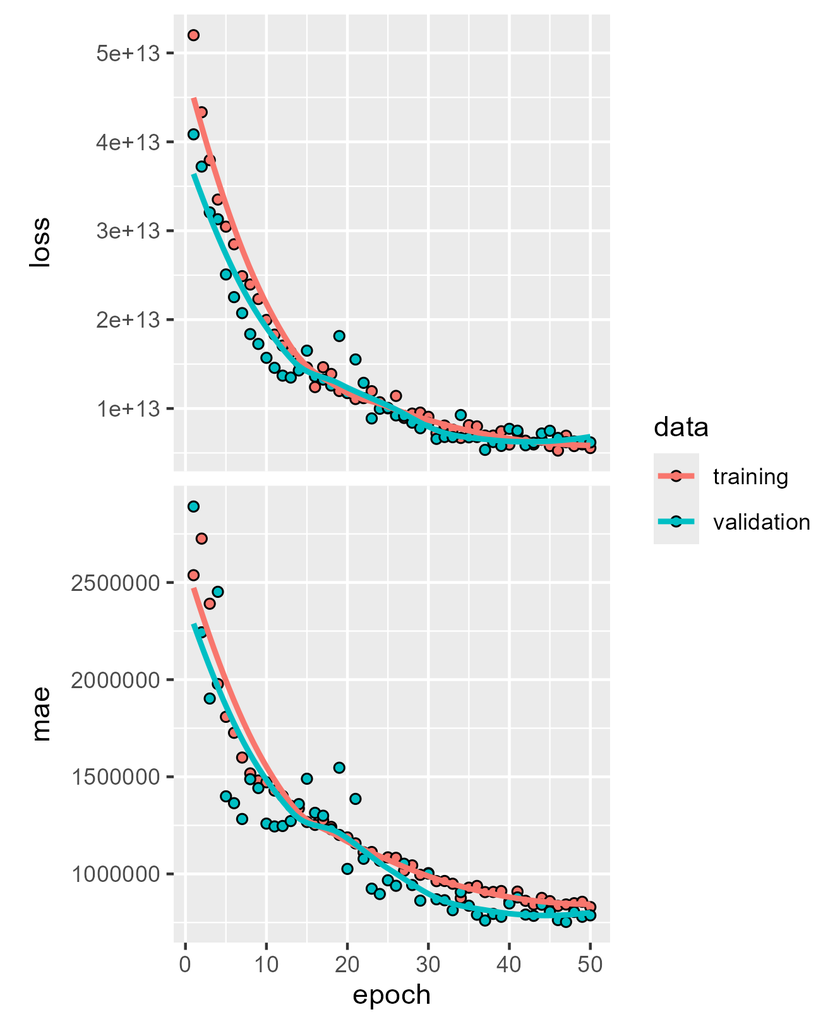

```r
#grafico history
plot(history)
```

Dopo aver trovato l’architettura del modello ho provato ad aumentare il numero di epoche per vedere quale fosse il numero ottimale per cui il Mean Absolute Error si stabilizza intorno ad un certo valore. In questo caso dopo aver provato numero_di_epoche = 150 ho notato che già intorno all’epoca 40/45 il MAE raggiunge convergenza. Dunque ho deciso di limitare il numero di epoche a 50 anche per ridurre la complessità computazionale ed i costi in termini di tempo ed energia. Nei seguenti grafici si può vedere che all’epoca 50 il valore dell’errore si stabilizza.

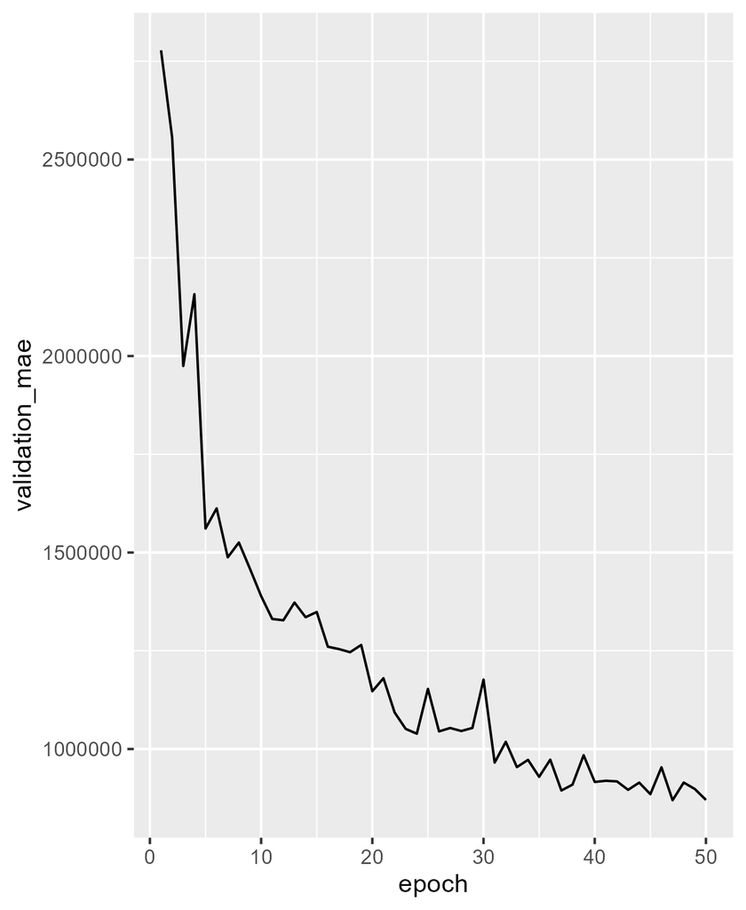

```r
#controllo mae
library(ggplot2)
ggplot(average_mae_history, aes(x = epoch, y = validation_mae)) + geom_line()
```

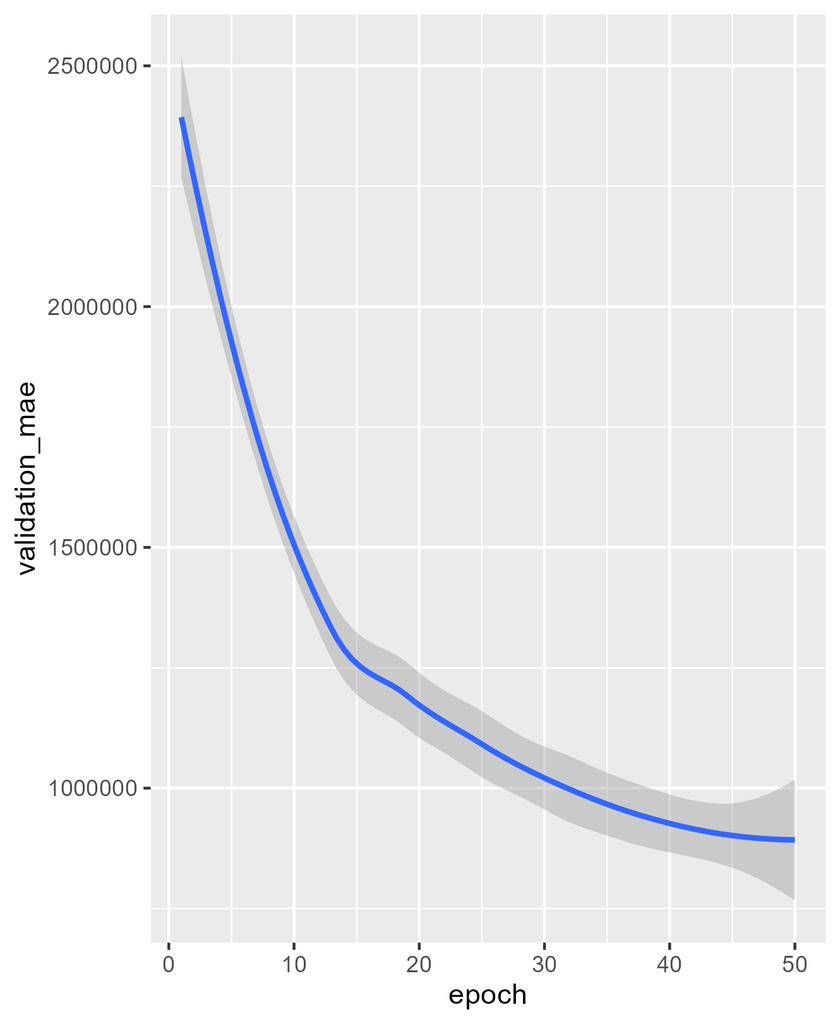

```r
ggplot(average_mae_history, aes(x = epoch, y = validation_mae)) + geom_smooth()
```

## 4.Conclusioni

```r
#RANDOM FOREST

#rf.model.tr<- randomForest(value ~., data = x_train ,mtry = 12, nodesize = 5)

y_rf_test = predict(rf.model, newdata = as.data.frame(x_test))
mae_rf_test <- mean(abs(x_test$value-y_rf_test))
mae_rf_test
```

```
## [1] 741347.9
```

Dunque anche in fase di test il modello ha fornito buoni risultati. Successivamente ho cercato di capire il motivo per cui RandomForest e Bagging performano meglio rispetto ad un algoritmo di Boosting sui dati in esame.

Questo probabilmente potrebbe essere dovuto a diversi fattori. Per prima cosa la natura della variabile target ‘Value’. Questa variabile infatti presenta una distribuzione molto asimmetrica, come si può vedere dal boxplot, ed anche una varianza altissima. L’idea è quella che metodi come Bagging e RandomForest utilizzano un ensamble di alberi in parallelo e non in sequenza come il boosting, rendendo le stime più robuste e cercando di ridurre la varianza a discapito magari di un aumento del bias.

Entrambi questi modelli utilizzano un campionamento bootstrap sui dati ed applicano un decision tree per ogni campione ottenuto. Questo fa sì che la correlazione tra i vari alberi sia relativamente bassa e introduce diversità tra i vari decision trees. Successivamente mediante l’aggregazione dei risultati attraverso la media le previsioni vengono stabilizzate. La Random Forest invece, oltre al campionamento Bootstrap, introduce anche una selezione casuale delle features tra cui scegliere quella per effettuare lo split. Questo garantisce che gli alberi siano ancora più incorrelati e diversi tra loro. Per verificare questo aspetto ho deciso di controllare la correlazione media tra i diversi alberi sia per il Bagging, sia per la RandomForest. I risultati ottenuti hanno confermato che l’algoritmo RandomForest ha una correlazione media tra diversi alberi sempre minore rispetto a quella ottenuta con il Bagging.

```r
#funzione per estrarre le previsioni (risultati)
extract_tree_predictions <- function(model, data) {
  n_trees <- model$ntree
  n_samples <- nrow(data)

  # Initialize a matrix to store predictions
  tree_preds <- matrix(NA, nrow = n_samples, ncol = n_trees)

  # Loop over each tree and get predictions
  for (i in 1:n_trees) {
    tree_preds[, i] <- predict(model, newdata = data, predict.all = TRUE)$individual[, i]
  }

  return(tree_preds)
}

preds = extract_tree_predictions(model.bag,x_train)

#funzione per calcolare correlazioni
calculate_tree_correlations <- function(tree_preds) {
  n_trees <- ncol(tree_preds)

  # Initialize a vector to store correlations
  correlations <- numeric()

  # Calculate pairwise correlations
  for (i in 1:(n_trees - 1)) {
    for (j in (i + 1):n_trees) {
      corr <- cor(tree_preds[, i], tree_preds[, j])
      correlations <- c(correlations, corr)
    }
  }

  return(correlations)
}
#calcolo correlazione bagging
preds = extract_tree_predictions(model.bag,x_train)
corr_bag = calculate_tree_correlations(preds)
#calcolo correlazione RandomForest
preds2 = extract_tree_predictions(rf.model,x_train)
corr_rf = calculate_tree_correlations(preds2)



#stampo i risultati
mean(corr_bag)
mean(corr_rf)
```

```
## [1] 0.8588308
```

```
## [1] 0.830872
```

Un altro motivo per cui potrebbero funzionare meglio RandomForest e Bagging è che il Boosting aggrega sequenzialmente una serie di alberi di decisione in modo da ridurre l’errore in modo iterativo. Il boosting rispetto al Bagging ed alla RandomForest è più sensibile alla scelta delle variabili per lo split. Essendo le mie variabili tutte poco informative tranne la variabile Reactions, il Boosting potrebbe non trarne vantaggio e performare peggio.

Dal progetto ho capito che per determinate tipologie di dati, modelli più semplici possono performare meglio sia in termini di errore sia in termini di complessità computazionale rispetto ad altri.

Lorenzo De Simoni